# Python for Babies 1

GDSC Waseda

2021-11-26

# 1 Installation

## 1.1 Python

**Mac**

- Using [Homebrew](https://docs.python-guide.org/starting/install3/osx/) - general purpose. Suitable for people who want a basic package manager that works like a Linux package manager.
- Using [Anaconda](https://docs.anaconda.com/anaconda/install/mac-os/) - suitable for people interested in using python for data science.

**Windows**

- [Raw install](https://phoenixnap.com/kb/how-to-install-python-3-windows)
- Using [Anaconda](https://docs.anaconda.com/anaconda/install/windows/) - suitable for people interested in using python for data science.

**Linux**

- Use package manager.

## 1.2 Visual Studio Code

- Choose the option for your environment from [here](https://code.visualstudio.com/downloadhttps://code.visualstudio.com/download)

## 1.3 iPython

- If you downloaded python via the Anaconda distribution, ipython is already installed.
- Otherwise, you must install iPython via pip. Open your *terminal* and execute the following code:

For those with homebrew:

```bash
$ brew install python
$ rehash
$ pip3 install ipython
$ rehash
```

Otherwise:

```bash
$ pip install ipython
```

# 2 Setting Up

1. Open Visual Studio Code. You’ll see something like this:

[figure not shown]

2. Click on New File, and then Text File

[figure not shown]

3. Click on Select Language

[figure not shown]

4. Input Python

[figure not shown]

5. Hooray! We have a .py file ready to go! Now, before we do anything with this file, we want to open up an *interactive* terminal. Go to your toolbar and click on Terminal, then New Terminal:

[figure not shown]

6. Now we have a terminal! But oh wait, it’s not running Python. Type in

```bash
$ ipython
```

[figure not shown]

7. If you see a screen like the one below, you’re ready to go! Try typing in “print(‘hello world’)” into the terminal

[figure not shown]

# 3 Terminal vs. File

The difference between the interactive terminal and the file is that the interactive terminal takes in commands one by one, while the file reads the **entire file** once before evaluating commands. We’re gonna see how this works in a minute.

First, try typing in *print(‘hello world’)* into the ipython terminal. You should get something like this:

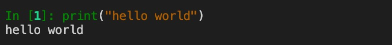

Now, let’s see what the file does. First, write the same command *print(‘hello world’)* in the file.

[figure not shown]

Next, save the file and give it the name “helloworld.py”. When you save the file, make sure to save it in a folder (aka directory) that you are familiar with. For example, I saved my file in “~/GDSC/python_for_babies/helloworld.py” where “GDSC” and “python_for_babies” are *directories*, or folders that lead to “helloworld.py”. If this concept is foreign to you, I’ll take some time to explain.

[figure not shown]

Now, go back to the ipython terminal. Unfortunately, we can’t call “helloworld.py” from inside the python terminal. We have to call it from our bash terminal. Type “quit()” to quit ipython, and direct yourself to the directory that contains “helloworld.py”. The following commands will help you

```bash
$ ls
# lists all the subdirectories and files in the current directory
$ cd (directory_name)
# navigates to (directory_name)
```

Pay attention to how I use the two commands to find out where I am, and direct myself to the target directory.

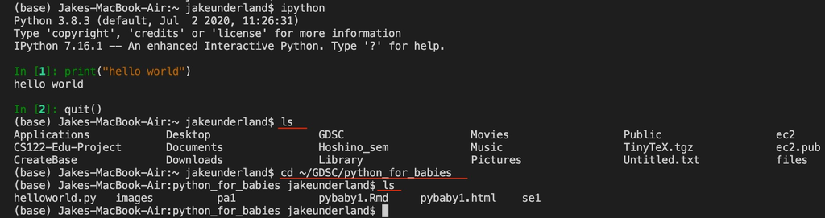

YAY! We’re finally ready to run the file *helloworld.py*. Enter the following:

```bash
$ python3 helloworld.py
```

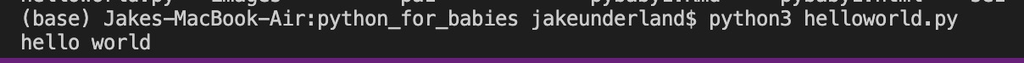

Now let’s try something a bit different. Go to the file and add a few lines:

[figure not shown]

What does this output?

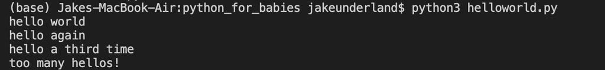

This shows us that the file executes all the code contained in it, while the terminal just takes one command after another. Neat! Now we have the know-how of writing code in python with visual studio code.

# 4 Building Blocks

Now it’s time to actually start learning how to code!

## 4.1 Variables

In programming, we can assign a name to different data and store it in a convenient manner. These names are called variables. The python syntax for it is below:

```python
variable = "Hello, world!"
```

now try printing the variable

```python
print(variable)
```

```
## Hello, world!
```

Neat!

You can also do stuff like the following:

```python
a = 5 + 2
print(a)
```

```
## 7
```

```python
b = a + 2
print(b)
```

```
## 9
```

```python
c = 2 * a + 3 * b
print(c)
```

```
## 41
```

## 4.2 Data Types

- Integers e.g. (1, 2, -4)
- Floats (Real numbers, e.g., 1.3, 5.44, 2.0)
- Strings (Characters encased in "" or ’’, e.g. “Hello world”)
- Boolean (e.g., True, False)

### 4.2.1 Arithmetic

```python
# by the way this is a comment
# a comment does not affect the code
# coments start with a hashtag
# Try the following commands:

2 + 3 # addition
2 - 3 # subtraction
2 * 3 # multiplication
2 / 3 # division
2 // 3 # division dropping remainder
2 ** 3 # exponents
16 % 5 # the modular operator
```

### 4.2.2 String Operations

```python
# Try the following commands:

message1 = "Hello"
message2 = "World"
message3 = message1 + message2  # concatenation
message4 = """
This is a long string.
It takes more than two lines.
"""
message5 = message1 + " " + message2

message6 = " ".join(message1)

# print these to see what they do!
```

### 4.2.3 Boolean Operations

```python
2 == 2 # equal
2 != 2 # unequal
2 != 3
2 > 3 # greater than
2 < 3 # less than
2 >= 2 # less than or equal to
2 >= 3 # greater than or equal to
2 >= 1
a = 6**6
a > 5
a < 100000
a == 6**6
```

## 4.3 Data Structures

There are many data structures in python, but for now we focus on lists.

Lists take the following form,

```python
lst = ["a", "b", "c", "d", "e"]
```

They are exactly what their name indicates, a list of datapoints.  
We can access the elements of a list in the following way:

```python
lst[1]
```

```
## 'b'
```

```python
lst[2]
```

```
## 'c'
```

This is called **indexing**. But, oh no! The above commands are not returning the first and second elements of the list!  
That is because in most programming languages, we always count from **0**.

```python
lst[0]
```

```
## 'a'
```

```python
lst[1]
```

```
## 'b'
```

```python
lst[-1] # last element of list
```

```
## 'e'
```

```python
lst[-2] # second to last element of list
```

```
## 'd'
```

You can take slices of a list

```python
lst[3:] # take the elements of the list from 4th position
```

```
## ['d', 'e']
```

```python
lst[:3] # take the elements of the list up to 3rd position (not including 4th)
```

```
## ['a', 'b', 'c']
```

```python
lst[1:3] # take the 2nd and 3rd elements of the list.
```

```
## ['b', 'c']
```

Notice that the lower bound is inclusive, but the upper bound is not.

You can also treat strings like a list

```python
a = "Hello world!"
print(a[0])
```

```
## H
```

```python
print(a[-1])
```

```
## !
```

```python
print(a[0:5])
```

```
## Hello
```

## 4.4 Control Flow Statements

### 4.4.1 For Loops

**for loops** are among the most basic operations in code.

They follow the following formula:

```bash
for <variable> in <sequence>:
    <statement>
```

Let’s look at a few examples.

```python
for p in [10, 25, 5, 70, 10]:
    print "The price is", p # you can print several things at once
```

```
## The price is 10
## The price is 25
## The price is 5
## The price is 70
## The price is 10
```

```python
prices = [10, 25, 5, 70, 10]
tax = 0.10
for p in prices:
    p = p * (1 + tax) # overwriting value of p
    print "The price with tax is", p
```

```
## The price with tax is 11.0
## The price with tax is 27.5
## The price with tax is 5.5
## The price with tax is 77.0
## The price with tax is 11.0
```

What if we want to know the total amount spent?

```python
prices = [10, 25, 5, 70, 10]
tax = 0.10
total = 0 # total begins with 0
for p in prices:
    p = p * (1 + tax)
    total += p # increment total by p
    print "The price with tax is", p
```

```
## The price with tax is 11.0
## The price with tax is 27.5
## The price with tax is 5.5
## The price with tax is 77.0
## The price with tax is 11.0
```

```python
print "The total price is", total
```

```
## The total price is 132.0
```

### 4.4.2 Conditionals

Conditionals take the following form:

```bash
if <boolean expression>:
    <statement>
else:
    <statement>
```

```python
a = 5
if a > 5:
    print("a is greater than 5")
else:
    print("a is less than or equal to 5")
```

```
## a is less than or equal to 5
```

But wait, what if I want to know if $a$ is exactly equal to 5?

```python
a = 5
if a > 5:
    print("a is greater than 5")
elif a == 5:    # we call this an else-if or if-else statement
    print("a is exactly equal to 5")
else:
    print("a is less than 5")
```

```
## a is exactly equal to 5
```

Let’s combine this with a for loop:

```python
prices = [10, 25, 5, 70, 10]
tax = 0.10
for p in prices:
    if p >= 20:
        p = p * (1 + tax) # overwriting value of p
    else:
        p = p
    print "The price with tax is", p
```

```
## The price with tax is 10
## The price with tax is 27.5
## The price with tax is 5
## The price with tax is 77.0
## The price with tax is 10
```

But, $p = p$ is a redundant statement! Just take that out.

```python
prices = [10, 25, 5, 70, 10]
tax = 0.10
for p in prices:
    if p >= 20:
        p = p * (1 + tax) # overwriting value of p
    print "The price with tax is", p
```

```
## The price with tax is 10
## The price with tax is 27.5
## The price with tax is 5
## The price with tax is 77.0
## The price with tax is 10
```

Same result! What if we want the total price of just taxable products?

```python
prices = [10, 25, 5, 70, 10]
tax = 0.10
total_taxable = 0
for p in prices:
    if p >= 20:
        p = p * (1 + tax) # overwriting value of p
        total_taxable += p
    print "The price with tax is", p
```

```
## The price with tax is 10
## The price with tax is 27.5
## The price with tax is 5
## The price with tax is 77.0
## The price with tax is 10
```

```python
print "The total of taxable products is", total_taxable
```

```
## The total of taxable products is 104.5
```

How about the total of nontaxable products?

```python
prices = [10, 25, 5, 70, 10]
tax = 0.10
total_taxable = 0
total_nontaxable = 0
for p in prices:
    if p >= 20:
        p = p * (1 + tax) # overwriting value of p
        total_taxable += p
    else:
        total_nontaxable += p
    print "The price with tax is", p
```

```
## The price with tax is 10
## The price with tax is 27.5
## The price with tax is 5
## The price with tax is 77.0
## The price with tax is 10
```

```python
print "The total of taxable products is", total_taxable
```

```
## The total of taxable products is 104.5
```

```python
print "The total of nontaxable products is", total_nontaxable
```

```
## The total of nontaxable products is 25
```

## 4.5 Functions

We can wrap our code in functions so that we can reuse it later! The basic structure of a function is this:

```bash
def <name>(<input_variables>):
    <statement>
    return <target variable>
```

```python
def square(x):
    x2 = x * x # or x ** 2
    return x2
print(square(3))
```

```
## 9
```